# Homework #3 Binary logistic regression models

Douglas Barley, Ethan Haley, Isabel Magnus, John Mazon, Vinayak Kamath

10/11/2021

DATA 621 – Business Analytics and Data Mining

Homework #3 Assignment Requirements  
In this homework assignment, you will explore, analyze and model a data set containing information on crime for various neighborhoods of a major city. Each record has a response variable indicating whether or not the crime rate is above the median crime rate (1) or not (0).

# Overview

```r
crime_eval_df <- read.csv("https://raw.githubusercontent.com/johnm1990/DATA621/main/hw3/crime-evaluation-data_modified.csv")
crime_train_df <- read.csv("https://raw.githubusercontent.com/johnm1990/DATA621/main/hw3/crime-training-data_modified.csv")
```

```r
head(crime_train_df, 1)
```

```
##   zn indus chas   nox    rm  age    dis rad tax ptratio lstat medv target
## 1  0 19.58    0 0.605 7.929 96.2 2.0459   5 403    14.7   3.7   50      1
```

```r
crime_train_df$target <-  as.factor(crime_train_df$target)
```

Go through the predictors in order.

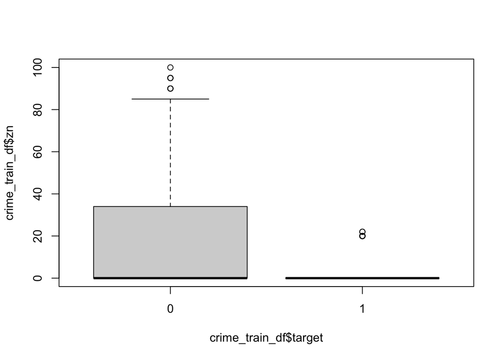

```r
boxplot(crime_train_df$zn ~ crime_train_df$target)
```

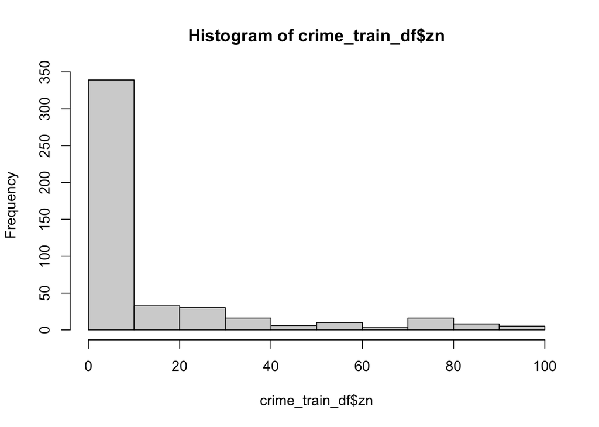

```r
hist(crime_train_df$zn)
```

How many different values are there in that below 10 range?

```r
table(crime_train_df$zn[crime_train_df$zn<10])
```

```
##
##   0
## 339
```

What does the rest of the histogram look like?

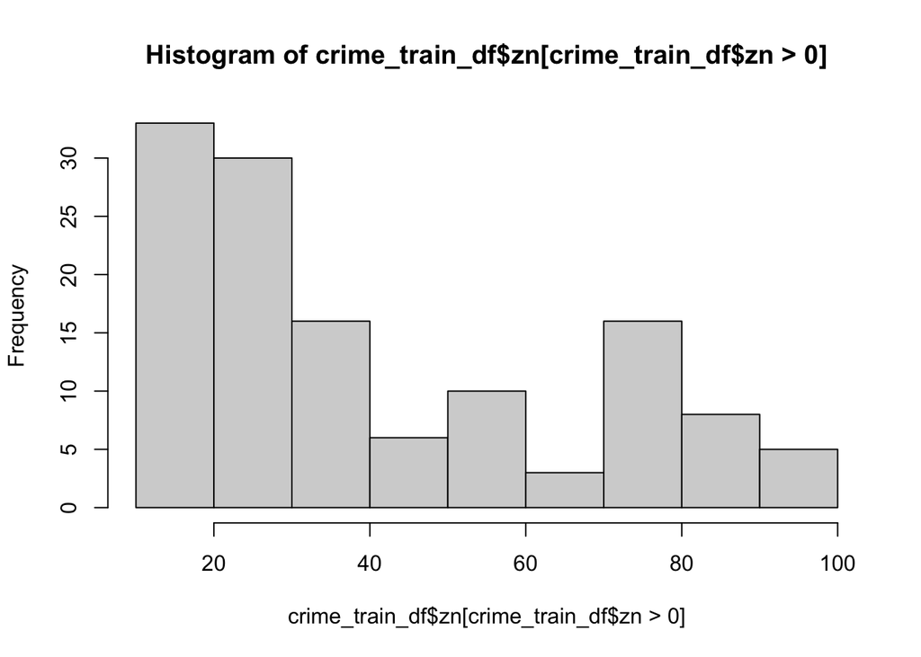

```r
hist(crime_train_df$zn[crime_train_df$zn>0])
```

Is there a cutoff where every value corresponds to the same target?

```r
table(crime_train_df$target[crime_train_df$zn > 22])
```

```
##
##  0  1
## 81  0
```

```r
crime_train_df['zn_hi'] = crime_train_df$zn > 22
```

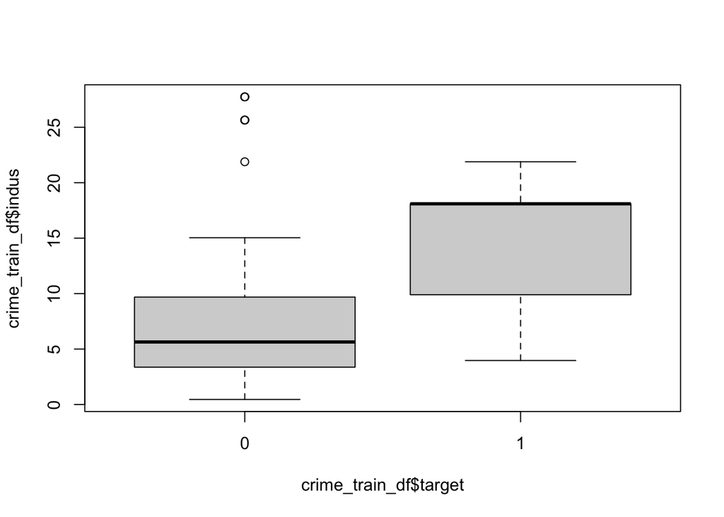

```r
boxplot(crime_train_df$indus ~ crime_train_df$target)
```

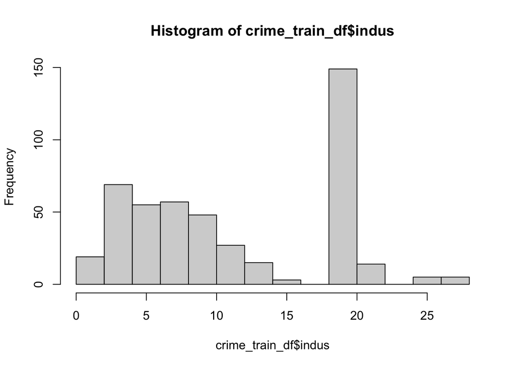

```r
hist(crime_train_df$indus)
```

Is that just one value dominating the histogram?

```r
table(crime_train_df$indus[crime_train_df$indus > 18])
```

```
##
##  18.1 19.58 21.89 25.65 27.74
##   121    28    14     5     5
```

Why are there so many exact values in the 18-20 area? Apparently those directly determine the target:

```r
table(crime_train_df$target[(crime_train_df$indus>18) & (crime_train_df$indus<20)])
```

```
##
##   0   1
##   0 149
```

```r
table(crime_train_df$target[(crime_train_df$indus>20)])
```

```
##
##  0  1
## 11 13
```

Make a dummy indicator for 18<indus<20

```r
crime_train_df['indus19'] = crime_train_df$indus > 18 & crime_train_df$indus < 20
```

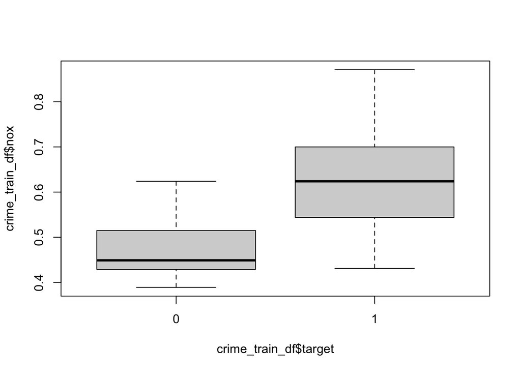

```r
boxplot(crime_train_df$nox ~ crime_train_df$target)
```

Leave that for now at least.

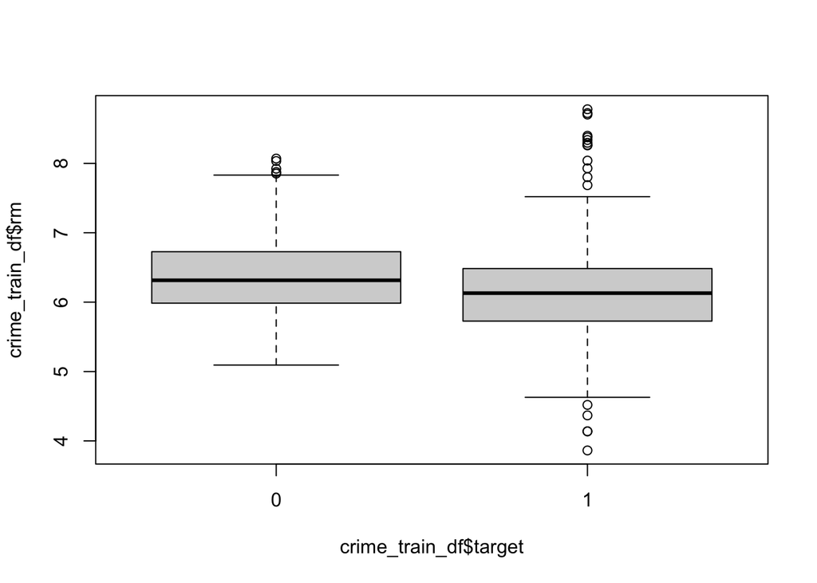

```r
boxplot(crime_train_df$rm ~ crime_train_df$target)
```

Looks normal, for this dataset.

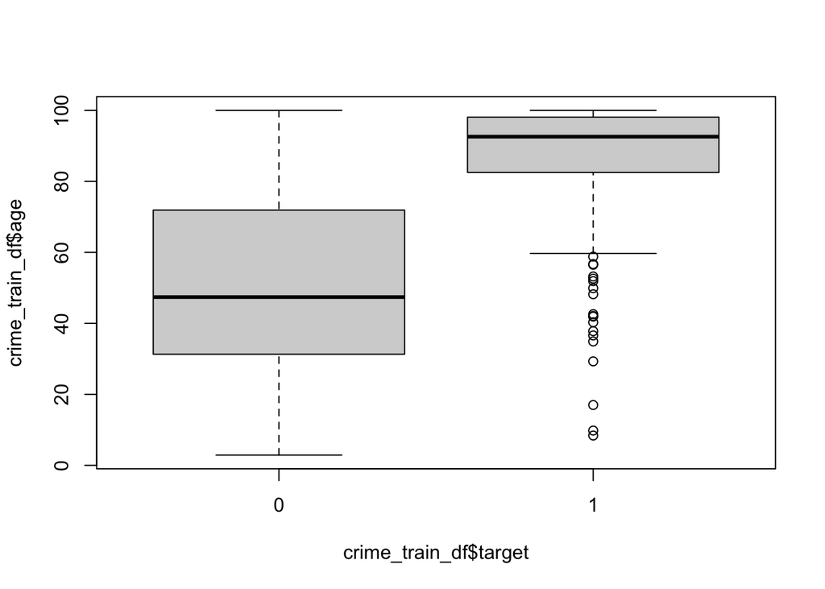

```r
boxplot(crime_train_df$age ~ crime_train_df$target)
```

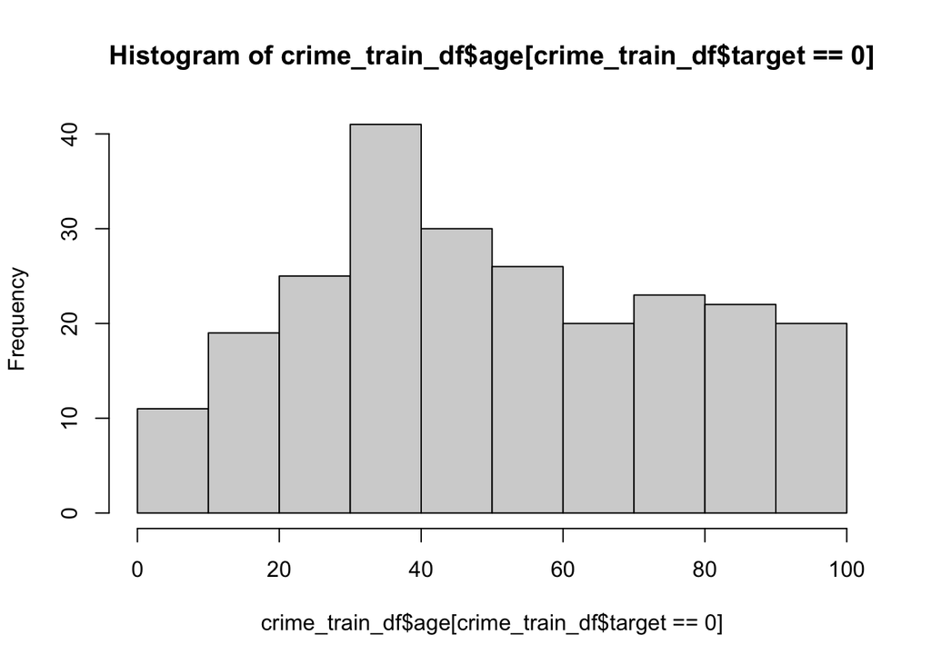

```r
hist(crime_train_df$age[crime_train_df$target==0])
```

That looks normal for the lower crime areas. How about the higher ones?

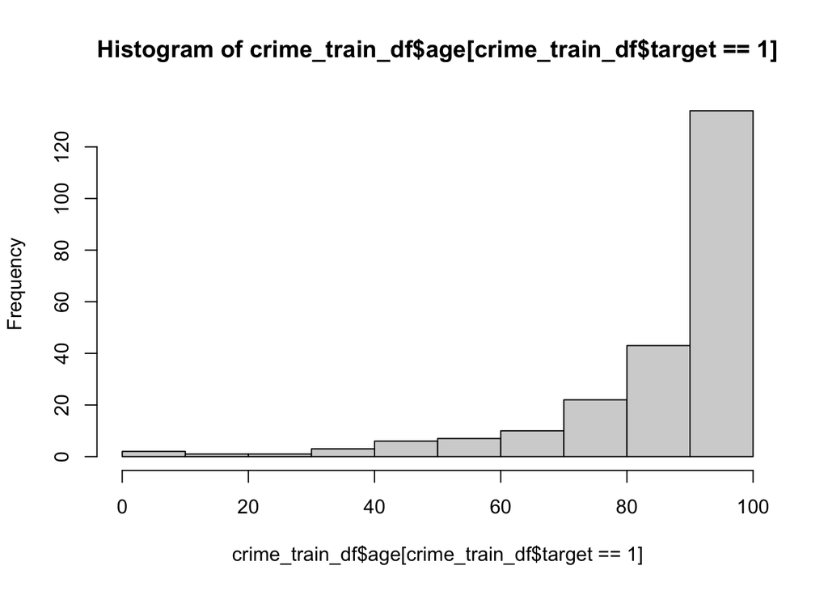

```r
hist(crime_train_df$age[crime_train_df$target==1])
```

```r
crime_train_df['sq_age'] = crime_train_df$age ** 2
```

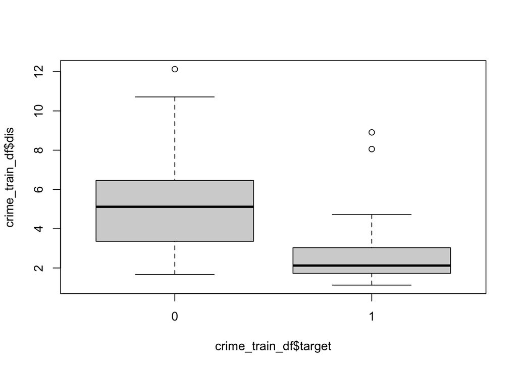

```r
boxplot(crime_train_df$dis ~ crime_train_df$target)
```

```r
sd(crime_train_df$dis[crime_train_df$target==1])
```

```
## [1] 1.078999
```

```r
sd(crime_train_df$dis[crime_train_df$target==0])
```

```
## [1] 2.067398
```

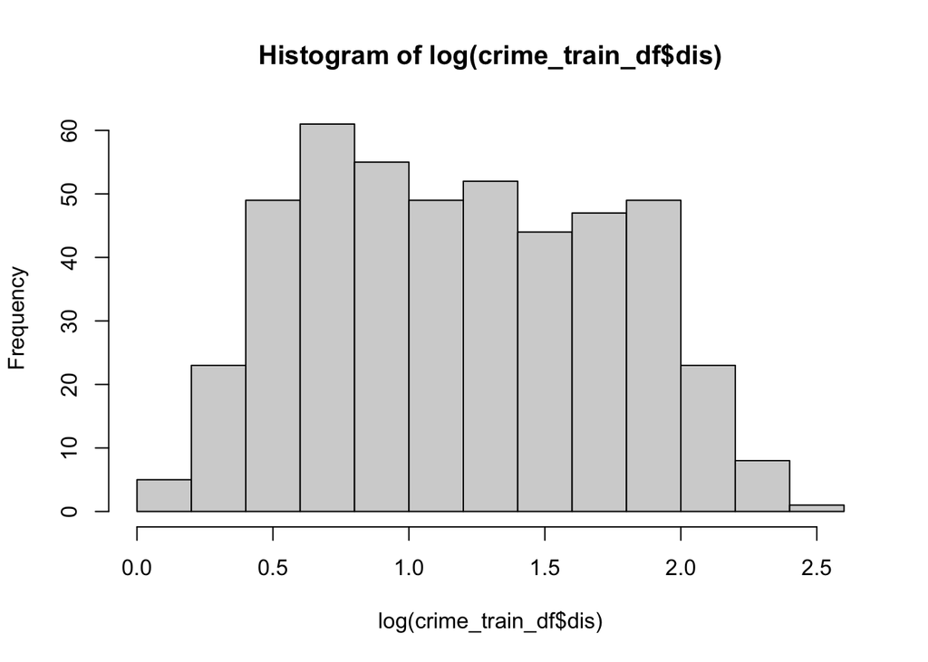

```r
hist(log(crime_train_df$dis))
```

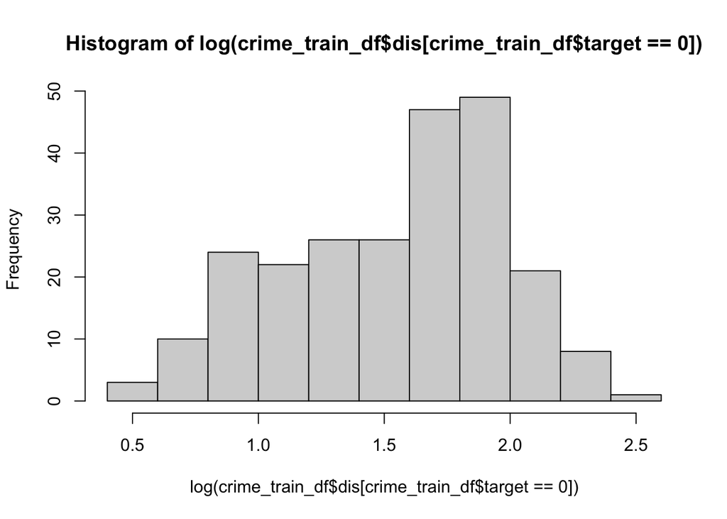

```r
hist(log(crime_train_df$dis[crime_train_df$target==0]))
```

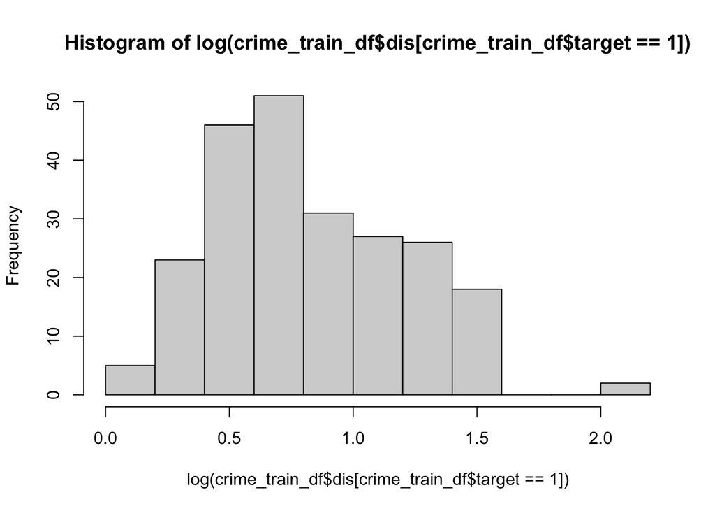

```r
hist(log(crime_train_df$dis[crime_train_df$target==1]))
```

Taking the log normalizes the predictor conditioned on the response, so log_dis should be useful.

```r
crime_train_df['log_dis'] = log(crime_train_df$dis)
```

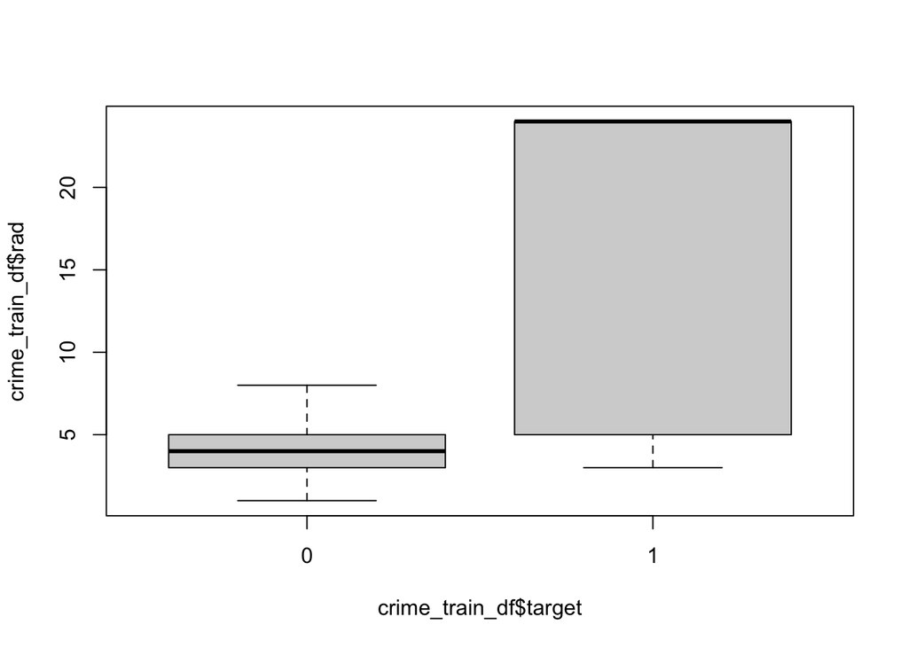

```r
boxplot(crime_train_df$rad ~ crime_train_df$target)
```

```r
sd(crime_train_df$rad[crime_train_df$target==1])
```

```
## [1] 9.514932
```

```r
sd(crime_train_df$rad[crime_train_df$target==0])
```

```
## [1] 1.594359
```

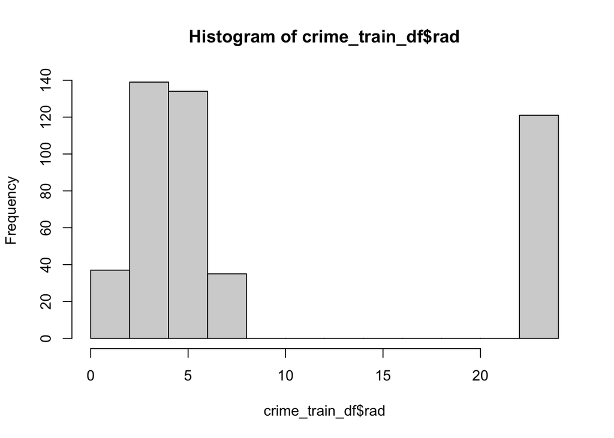

```r
hist(crime_train_df$rad)
```

```r
table(crime_train_df$target[crime_train_df$rad>15])
```

```
##
##   0   1
##   0 121
```

Does this maybe just overlap with indus19 though?

```r
mean(crime_train_df$indus19[crime_train_df$rad>8])
```

```
## [1] 1
```

Yes, that’s just redundancy. What about at the lower end of the range?

```r
mean(crime_train_df$indus19[crime_train_df$rad<5])
```

```
## [1] 0
```

So the only values of rad that aren’t redundant info, after adding indus 19, are 5<rad<8

```r
crime_train_df['rad5to8'] = 5 < crime_train_df$rad & crime_train_df$rad < 8
```

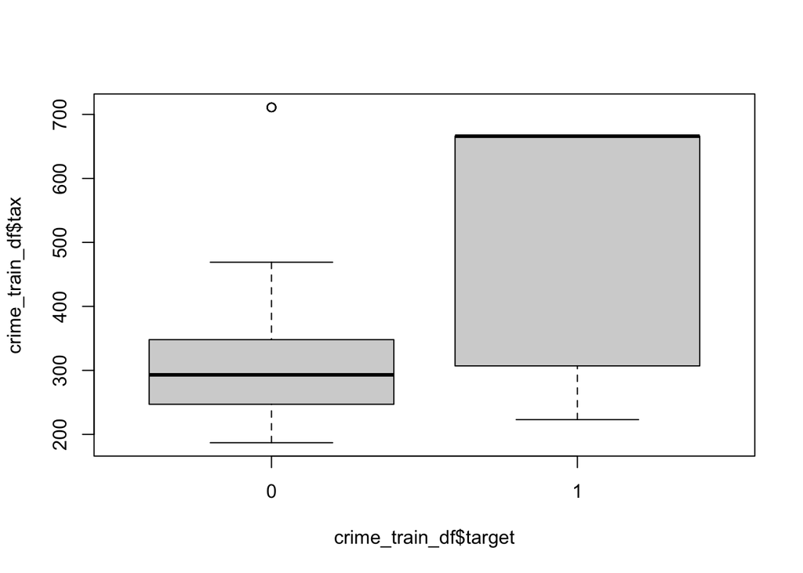

```r
boxplot(crime_train_df$tax ~ crime_train_df$target)
```

```r
sd(crime_train_df$tax[crime_train_df$target==1])
```

```
## [1] 166.6934
```

```r
sd(crime_train_df$tax[crime_train_df$target==0])
```

```
## [1] 89.19775
```

Very different variances

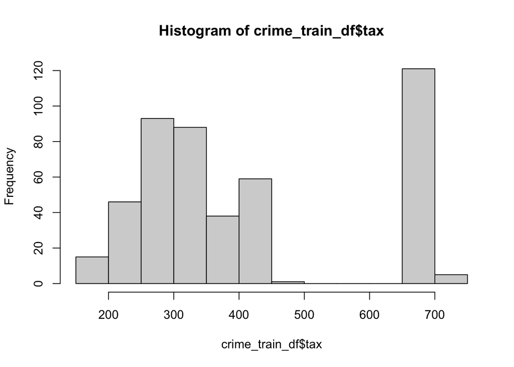

```r
hist(crime_train_df$tax)
```

```r
crime_train_df['log_tax'] = log(crime_train_df$tax)
```

```r
table(crime_train_df$tax[crime_train_df$tax>600])
```

```
##
## 666 711
## 121   5
```

That’s just weird, why 666?

```r
table(crime_train_df$target[crime_train_df$tax == 666])
```

```
##
##   0   1
##   0 121
```

That’s the same table as rad > 15. More redundancy probably.

```r
sum(crime_train_df$tax==666 & crime_train_df$rad>15)
```

```
## [1] 121
```

What about the tax == 711:

```r
table(crime_train_df$target[crime_train_df$tax==711])
```

```
##
## 0 1
## 5 0
```

Will indus19 take care of those 5, so that we can ignore tax > 600 ?

```r
sum(crime_train_df$tax==711 & crime_train_df$indus19)
```

```
## [1] 0
```

```r
table(crime_train_df$target[crime_train_df$tax==711 & !crime_train_df$indus19])
```

```
##
## 0 1
## 5 0
```

```r
crime_train_df['tax_666'] = crime_train_df$tax==666
```

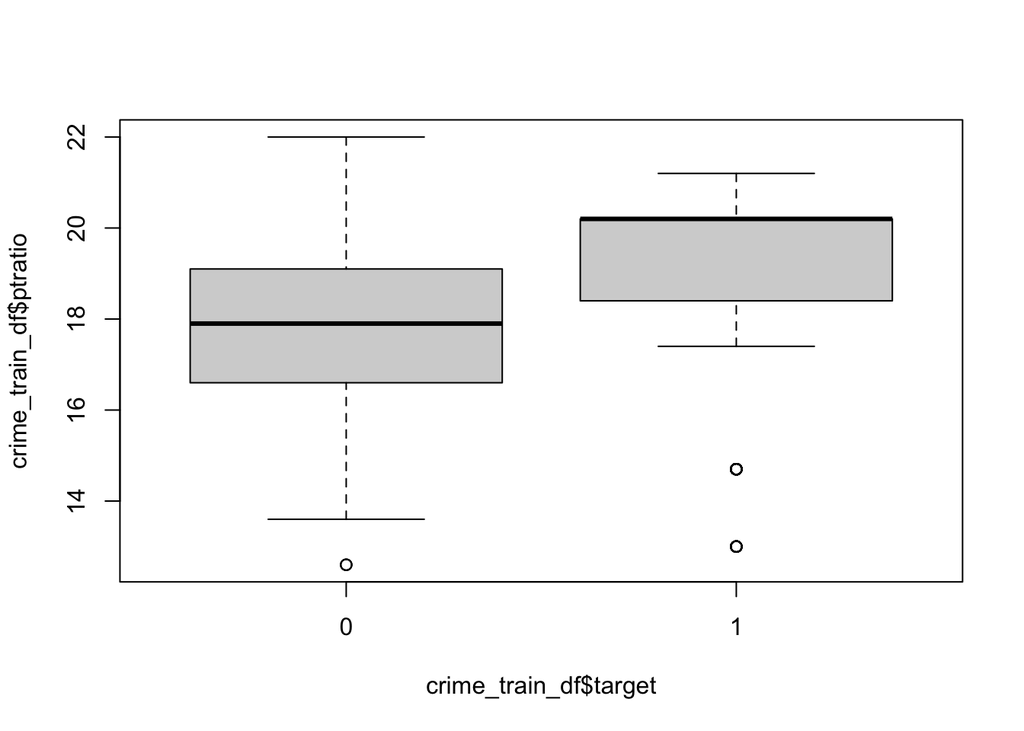

```r
boxplot(crime_train_df$ptratio ~ crime_train_df$target)
```

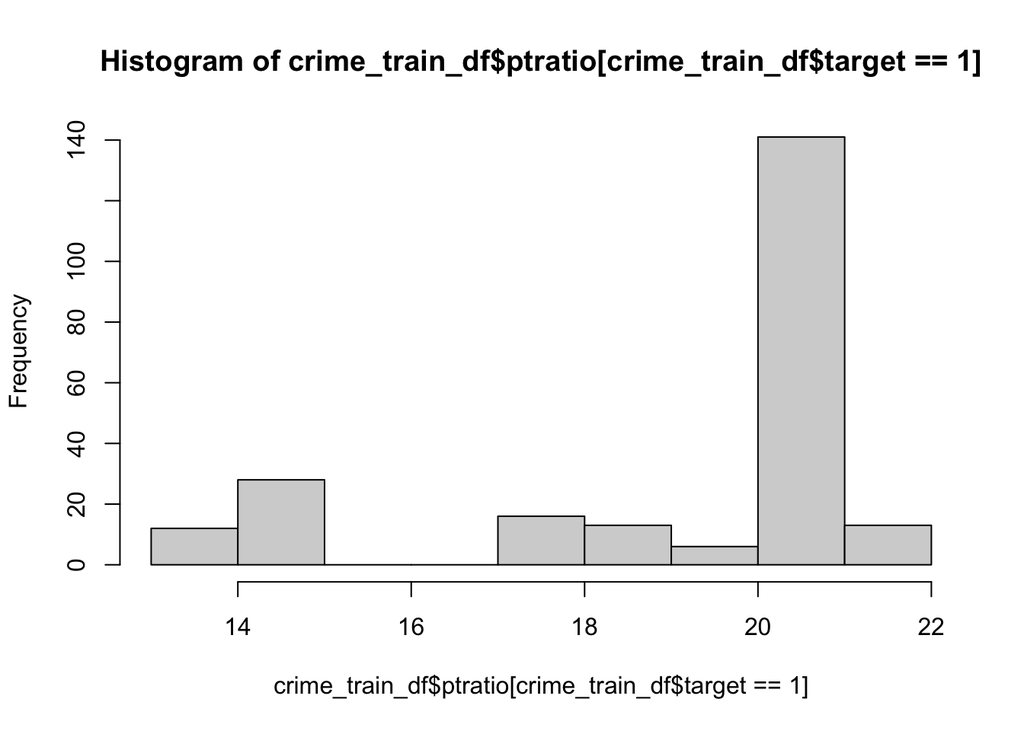

```r
hist(crime_train_df$ptratio[crime_train_df$target==1])
```

```r
table(crime_train_df$ptratio[crime_train_df$ptratio>19])
```

```
##
## 19.1 19.2 19.6 19.7 20.1 20.2 20.9   21 21.1 21.2   22
##   14   17    6    6    5  128   11   23    1   14    2
```

```r
table(crime_train_df$target[crime_train_df$ptratio==20.2])
```

```
##
##   0   1
##   7 121
```

```r
crime_train_df['pt_peak'] = crime_train_df$ptratio == 20.2
crime_train_df['log_ptrat'] = log(crime_train_df$ptratio)
```

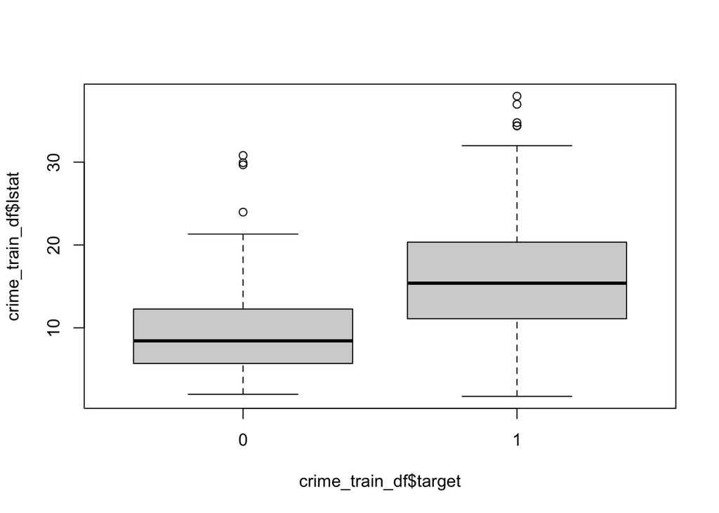

```r
boxplot(crime_train_df$lstat ~ crime_train_df$target)
```

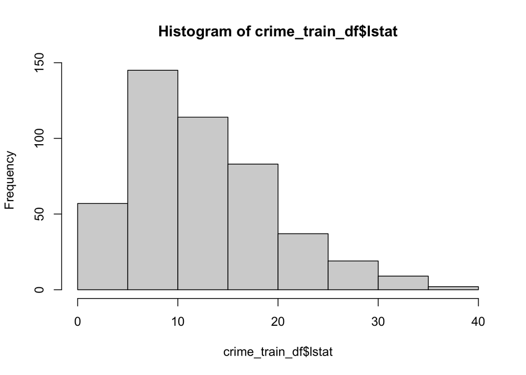

```r
hist(crime_train_df$lstat)
```

```r
crime_train_df['log_lstat'] = log(crime_train_df$lstat)
```

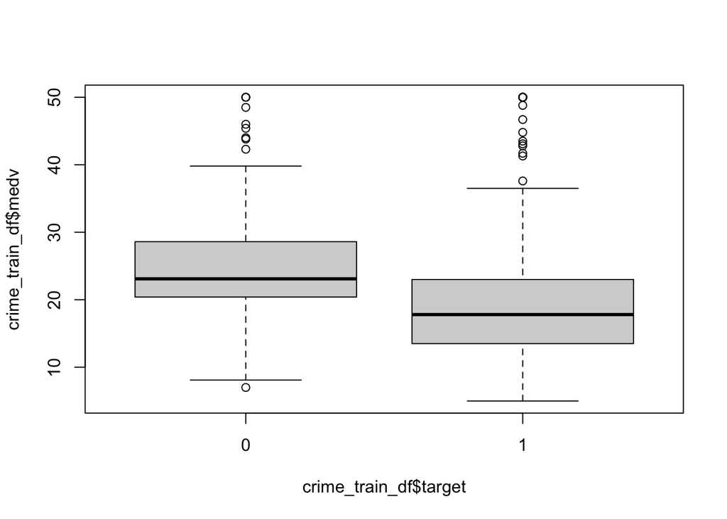

```r
boxplot(crime_train_df$medv ~ crime_train_df$target)
```

```r
names(crime_train_df)
```

```
##  [1] "zn"        "indus"     "chas"      "nox"       "rm"        "age"
##  [7] "dis"       "rad"       "tax"       "ptratio"   "lstat"     "medv"
## [13] "target"    "zn_hi"     "indus19"   "sq_age"    "log_dis"   "rad5to8"
## [19] "log_tax"   "tax_666"   "pt_peak"   "log_ptrat" "log_lstat"
```

```r
library(MASS)
library(caret)
set.seed(123)
split <- caret::createDataPartition(crime_train_df$target, p=0.90, list=FALSE)

train <- crime_train_df[split, ]
validation <- crime_train_df[ -split, ]

#Step 1: Create a full model
model.full  <- glm(target ~ . , data = train, family = 'binomial')
summary(model.full)
```

```
##
## Call:
## glm(formula = target ~ ., family = "binomial", data = train)
##
## Deviance Residuals:
##      Min        1Q    Median        3Q       Max
## -2.11946  -0.00003   0.00000   0.00000   2.17497
##
## Coefficients:
##               Estimate Std. Error z value Pr(>|z|)
## (Intercept) -1.559e+03  4.252e+02  -3.666 0.000246 ***
## zn           9.557e-01  2.506e-01   3.814 0.000137 ***
## indus        1.914e-01  2.294e-01   0.835 0.403999
## chas        -1.684e-01  1.447e+00  -0.116 0.907381
## nox          1.660e+02  4.040e+01   4.108 3.99e-05 ***
## rm          -5.077e+00  2.018e+00  -2.516 0.011865 *
## age          4.220e-02  7.123e-02   0.592 0.553557
## dis         -3.897e+00  2.215e+00  -1.760 0.078442 .
## rad          3.748e+00  1.015e+00   3.692 0.000222 ***
## tax         -5.897e-01  1.864e-01  -3.163 0.001560 **
## ptratio     -1.380e+01  5.227e+00  -2.639 0.008314 **
## lstat        7.078e-01  2.648e-01   2.673 0.007512 **
## medv         7.024e-01  2.237e-01   3.140 0.001690 **
## zn_hiTRUE   -7.762e+01  1.994e+03  -0.039 0.968942
## indus19TRUE  3.594e+01  6.221e+03   0.006 0.995390
## sq_age      -6.331e-06  5.901e-04  -0.011 0.991440
## log_dis      1.451e+01  7.928e+00   1.831 0.067143 .
## rad5to8TRUE -1.107e+01  3.085e+00  -3.589 0.000332 ***
## log_tax      1.691e+02  5.705e+01   2.964 0.003034 **
## tax_666TRUE  3.013e+00  1.987e+04   0.000 0.999879
## pt_peakTRUE -1.941e+01  1.873e+04  -0.001 0.999173
## log_ptrat    3.216e+02  1.052e+02   3.058 0.002228 **
## log_lstat   -7.259e+00  3.263e+00  -2.225 0.026096 *
## ---
## Signif. codes:  0 '***' 0.001 '**' 0.01 '*' 0.05 '.' 0.1 ' ' 1
##
## (Dispersion parameter for binomial family taken to be 1)
##
##     Null deviance: 583.514  on 420  degrees of freedom
## Residual deviance:  71.971  on 398  degrees of freedom
## AIC: 117.97
##
## Number of Fisher Scoring iterations: 21
```

```r
#Step 2: Create a backward model using the full model
model.backward <- model.full %>% stepAIC(direction = "backward", trace = FALSE)
summary(model.backward)
```

```
##
## Call:
## glm(formula = target ~ zn + nox + rm + age + dis + rad + tax +
##     ptratio + lstat + medv + zn_hi + indus19 + log_dis + rad5to8 +
##     log_tax + log_ptrat + log_lstat, family = "binomial", data = train)
##
## Deviance Residuals:
##      Min        1Q    Median        3Q       Max
## -2.19148  -0.00005   0.00000   0.00000   2.07352
##
## Coefficients:
##               Estimate Std. Error z value Pr(>|z|)
## (Intercept) -1.604e+03  3.697e+02  -4.340 1.42e-05 ***
## zn           9.403e-01  2.148e-01   4.378 1.20e-05 ***
## nox          1.711e+02  3.774e+01   4.534 5.77e-06 ***
## rm          -4.999e+00  1.963e+00  -2.546 0.010894 *
## age          4.196e-02  2.359e-02   1.779 0.075300 .
## dis         -3.081e+00  1.464e+00  -2.105 0.035307 *
## rad          3.456e+00  9.410e-01   3.673 0.000240 ***
## tax         -5.548e-01  1.316e-01  -4.216 2.49e-05 ***
## ptratio     -1.647e+01  4.814e+00  -3.422 0.000621 ***
## lstat        7.394e-01  2.359e-01   3.134 0.001722 **
## medv         6.963e-01  2.184e-01   3.188 0.001434 **
## zn_hiTRUE   -7.767e+01  3.314e+03  -0.023 0.981299
## indus19TRUE  3.451e+01  2.588e+03   0.013 0.989359
## log_dis      1.143e+01  5.903e+00   1.935 0.052931 .
## rad5to8TRUE -1.170e+01  2.881e+00  -4.062 4.87e-05 ***
## log_tax      1.612e+02  3.811e+01   4.229 2.35e-05 ***
## log_ptrat    3.668e+02  9.921e+01   3.697 0.000218 ***
## log_lstat   -7.670e+00  3.035e+00  -2.527 0.011490 *
## ---
## Signif. codes:  0 '***' 0.001 '**' 0.01 '*' 0.05 '.' 0.1 ' ' 1
##
## (Dispersion parameter for binomial family taken to be 1)
##
##     Null deviance: 583.514  on 420  degrees of freedom
## Residual deviance:  73.737  on 403  degrees of freedom
## AIC: 109.74
##
## Number of Fisher Scoring iterations: 22
```

```r
#Getting formula for the model
formula(model.backward)
```

```
## target ~ zn + nox + rm + age + dis + rad + tax + ptratio + lstat +
##     medv + zn_hi + indus19 + log_dis + rad5to8 + log_tax + log_ptrat +
##     log_lstat
```

```r
# generating the predictors
model.backward.pred =predict(model.backward, newdata = validation)
model.backward.pred[model.backward.pred >= 0.5] <- 1
model.backward.pred[model.backward.pred < 0.5] <- 0
model.backward.pred = as.factor(model.backward.pred)

#  generating the confusion matrix
model.backward.confusion.matrix <- confusionMatrix(model.backward.pred, validation$target, mode = "everything")

model.backward.confusion.matrix
```

```
## Confusion Matrix and Statistics
##
##           Reference
## Prediction  0  1
##          0 23  1
##          1  0 21
##
##                Accuracy : 0.9778
##                  95% CI : (0.8823, 0.9994)
##     No Information Rate : 0.5111
##     P-Value [Acc > NIR] : 3.366e-12
##
##                   Kappa : 0.9555
##
##  Mcnemar's Test P-Value : 1
##
##             Sensitivity : 1.0000
##             Specificity : 0.9545
##          Pos Pred Value : 0.9583
##          Neg Pred Value : 1.0000
##               Precision : 0.9583
##                  Recall : 1.0000
##                      F1 : 0.9787
##              Prevalence : 0.5111
##          Detection Rate : 0.5111
##    Detection Prevalence : 0.5333
##       Balanced Accuracy : 0.9773
##
##        'Positive' Class : 0
##
```